# Checkpoint 2 - Nível do PSA

Leonardo Alves dos Santos

March 30, 2016

```r
#Libraries
library(plyr)
library(dplyr)
library(ggplot2)
library(caret)
```

```r
#http://statweb.stanford.edu/~tibs/ElemStatLearn/datasets/prostate.data
prostate.data <- read.delim("./data/prostate.data.txt")
```

## Introdução

Os dados utilizados representam resultados de exames realizados em pacientes do sexo Masculino, com o objetivo de diagnosticar pacientes com Câncer de Prostata. O dataset possui os seguintes dados.

- vol: volume do câncer
- weight: peso do paciente
- age: idade do paciente
- bph: hiperplasia prostática benigna
- svi: invasão das vesículas seminais
- cp: penetração capsular
- gleason: escore Gleason
- pgg45: percentagem escore Gleason 4 ou 5
- psa: antígeno específico da próstata.

A ideia é, através de Regreção linear, criar um modelor apra prever os niveis de PSA no sangue do paciênte.

## Conhecendo Melhor os Dados

A idade dos pacientes avaliados é entre 41 e 79. A idade média é de 63.8659794. Como se pode observar no box plot abaixo, a maior parte deles tem idade entre 60 e 70 anos.

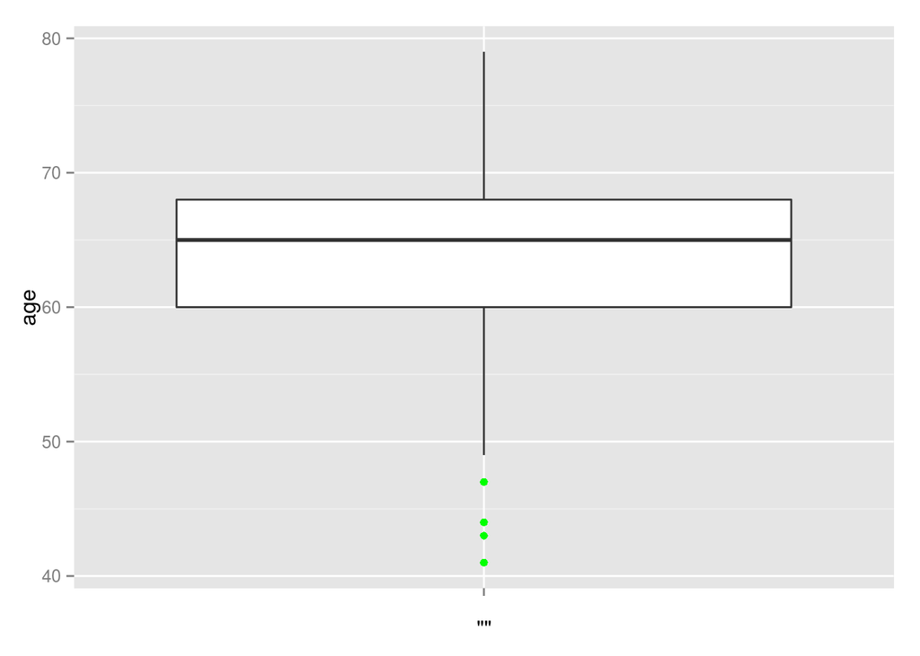

```r
boxplot_age <- ggplot(prostate.data, aes(y=age, x = ""))
boxplot_age+geom_boxplot(outlier.colour = 'green')
```

## Criando um primeiro Modelo

Muito se fala que homens a partir de uma certa idade devem começar a procurar um médico para prevenir o cancer de prostata. Um modelo inicial que pode ser feito é olhar a relação entre a idade e o nivel do PSA.

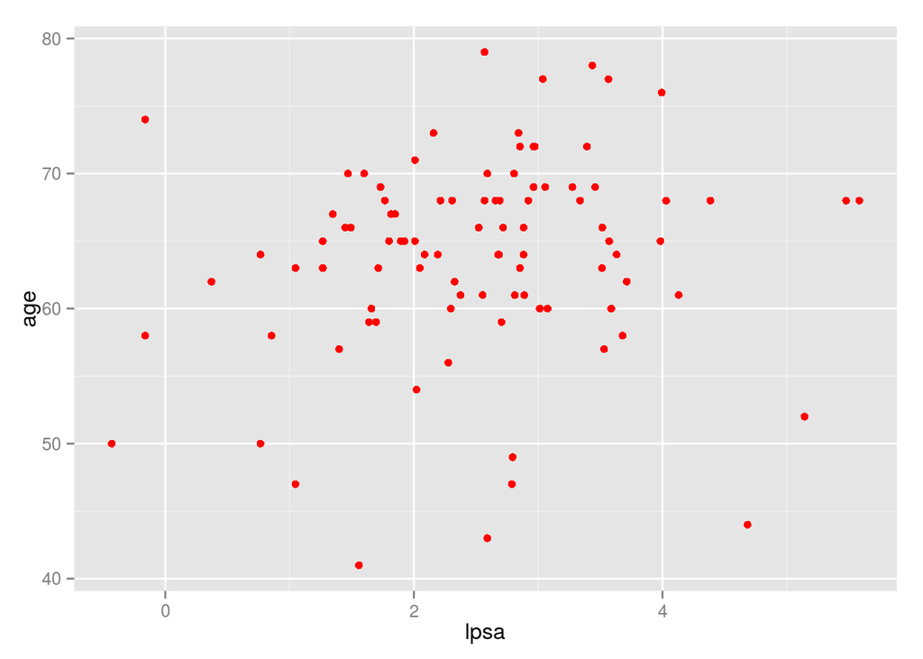

```r
plt_agexlpsa <- ggplot(prostate.data, aes(lpsa, age))
plt_agexlpsa+geom_point(colour = "red", size = 2)
```

Antes de criar o modelo, vamos separar os dados em treino e teste. Será removido a variável X pois ela indica soment o número da linha da entrada. Após a separação será removido a variável train pois ela só serve para separar os dados.

```r
prostate.data <- select(prostate.data, -X)

dados_treino <- prostate.data[prostate.data$train==TRUE,]
dados_treino$train <- NULL

dados_teste <- prostate.data[prostate.data$train==FALSE,]
dados_teste$train<- NULL
```

Vamos construir um modelo utilizando apenas a idade e lpsa (log do PSA).

```r
reg_linear = lm(lpsa ~ ., select(dados_treino, age,lpsa))
summary(reg_linear)
```

```
##
## Call:
## lm(formula = lpsa ~ ., data = select(dados_treino, age, lpsa))
##
## Residuals:
##      Min       1Q   Median       3Q      Max
## -2.95400 -0.67394  0.08716  0.70466  2.99243
##
## Coefficients:
##             Estimate Std. Error t value Pr(>|t|)
## (Intercept)  0.07945    1.26726   0.063   0.9502
## age          0.03665    0.01944   1.885   0.0639 .
## ---
## Signif. codes:  0 '***' 0.001 '**' 0.01 '*' 0.05 '.' 0.1 ' ' 1
##
## Residual standard error: 1.185 on 65 degrees of freedom
## Multiple R-squared:  0.05182,    Adjusted R-squared:  0.03723
## F-statistic: 3.552 on 1 and 65 DF,  p-value: 0.06393
```

## Melhorando o Modelo

Vimos que a idade por si só não é capaz de prever o nível de PSA. Vamos agorar verificar como fica um modelo usando todas as 8 variáveis dos dados de treino

```r
reg_multipla = lm(lpsa ~ ., dados_treino)
summary(reg_multipla)
```

```
##
## Call:
## lm(formula = lpsa ~ ., data = dados_treino)
##
## Residuals:
##      Min       1Q   Median       3Q      Max
## -1.64870 -0.34147 -0.05424  0.44941  1.48675
##
## Coefficients:
##              Estimate Std. Error t value Pr(>|t|)
## (Intercept)  0.429170   1.553588   0.276  0.78334
## lcavol       0.576543   0.107438   5.366 1.47e-06 ***
## lweight      0.614020   0.223216   2.751  0.00792 **
## age         -0.019001   0.013612  -1.396  0.16806
## lbph         0.144848   0.070457   2.056  0.04431 *
## svi          0.737209   0.298555   2.469  0.01651 *
## lcp         -0.206324   0.110516  -1.867  0.06697 .
## gleason     -0.029503   0.201136  -0.147  0.88389
## pgg45        0.009465   0.005447   1.738  0.08755 .
## ---
## Signif. codes:  0 '***' 0.001 '**' 0.01 '*' 0.05 '.' 0.1 ' ' 1
##
## Residual standard error: 0.7123 on 58 degrees of freedom
## Multiple R-squared:  0.6944, Adjusted R-squared:  0.6522
## F-statistic: 16.47 on 8 and 58 DF,  p-value: 2.042e-12
```

Ao contrário do modelo anterior esse modelo possui um p-valor pequeno. O que não nós permite rejeita-lo, com um bom nivel de significância, comoo um modelo para prever o PSA. O que iremos testar daqui para a frente é se ele é realmente um bom modelo, isto é, se os resultados das prediçẽos feitas por ele são bons, tem um erro baixo.

Começaremos inicialmente calculando as predições. Isto será feito usando os dados de teste. Também iremos calcular os residuos. Estes representam quanto o modelo errou, é a diferença entre o valor real e o valor predito pelo modelo.

```r
predicoes = predict.lm(reg_multipla, dados_teste)
residuos = dados_teste$lpsa - predicoes
```

Abaixo podemos ver os dados reais versos os preditos

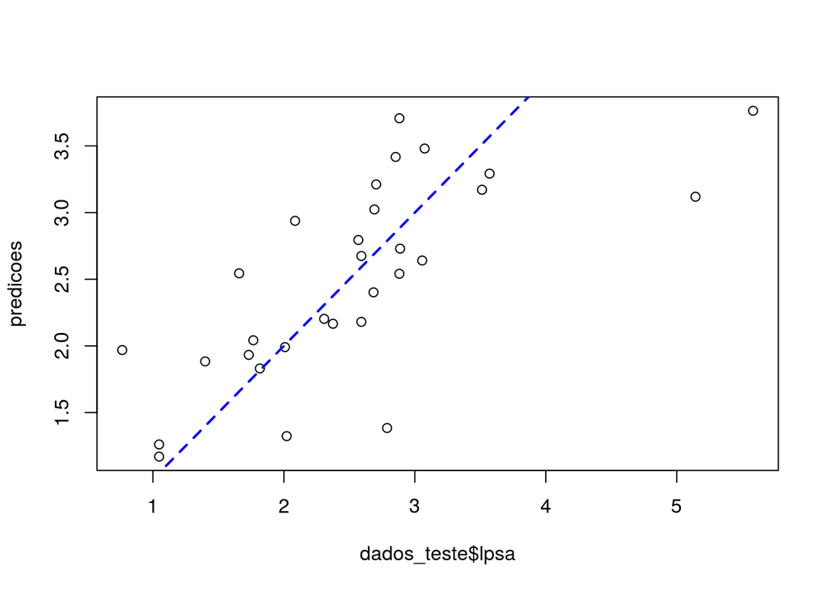

```r
axisRange = extendrange(c(dados_teste$lpsa,predicoes))
plot(dados_teste$lpsa,predicoes)
abline(0,1,col="blue",lty=2,lwd=2)
```

Com excessão de alguns outliers, os valores preditos, se aproximam dos valores reais. Outra forma de ver a relação acertos x erros é olhando o valor predito versus os residuos.

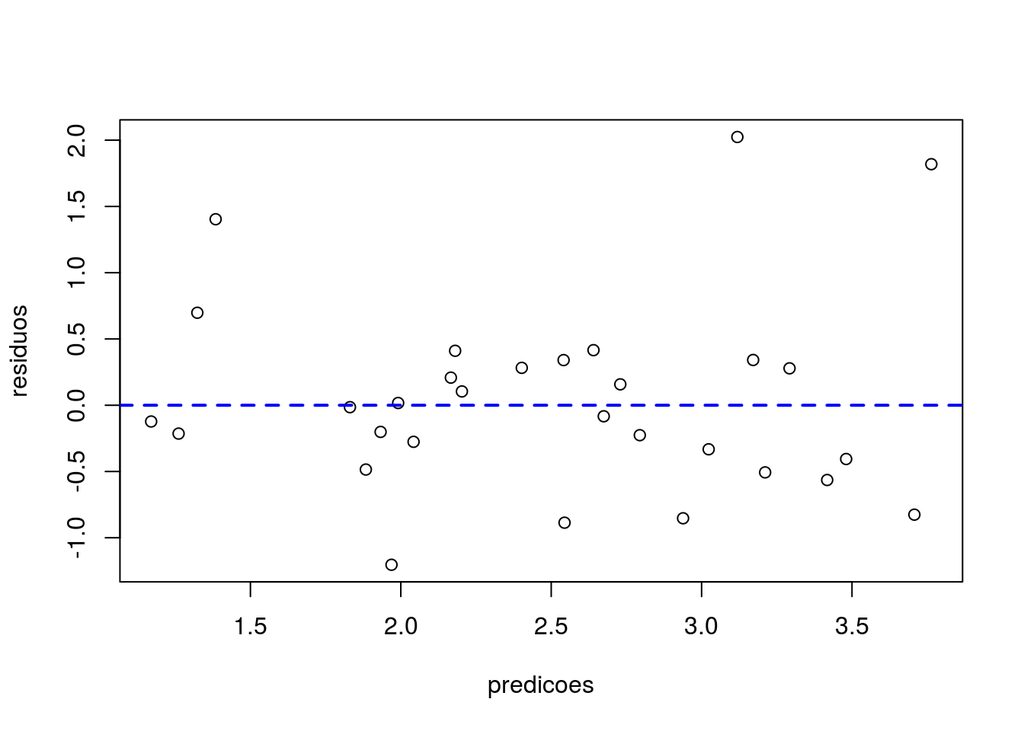

```r
plot(predicoes,residuos)
abline(h=0,col="blue",lty=2,lwd=2)
```

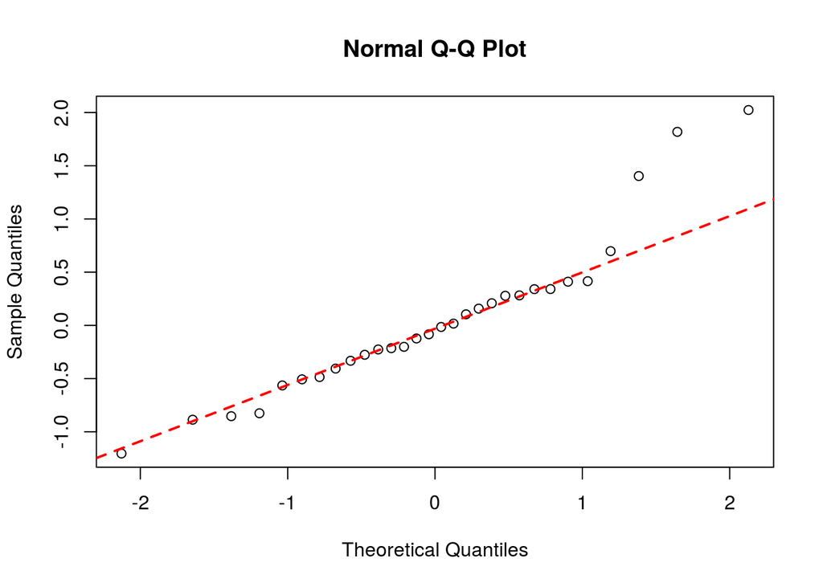

```r
qqnorm(residuos)
qqline(residuos, col = 2,lwd=2,lty=2)
```

Uma outra forma de vermos se temos um bom modelo é olhar o RMSE, quanto mais próximos de zero, melhor é o modelo analisado. Nosso modelo possui um RMSE de 0.7219931, o que é relativamente baixo, sendo assim podemos dizer que sim temos um modelo para prever o PSA.

## Conclusão

Podemos dizer que encontramos um modelo que é capaz de prever o PSA apresentando um baixo nivel de erros. Não podemos de dizer que este é o modelo perfeito para predizer, mas temos um modelo que causa baixos residuos.